# International Flight Forecasting

Team 5

8/26/2020

### Step 1. Read in data and check structure

#### Print rows

| V1 | fg_apt | usg_apt | data_dte | year | month | usg_apt_id | usg_wac | fg_apt_id | fg_wac | airlineid | carrier | carriergroup | type | scheduled | charter | total | in_flights | usg_icao | usg_airport | usg_city | usg_country | usg_latitude_decimal_degrees | usg_longitude_decimal_degrees | usg_in_iata | fg_icao | fg_airport | fg_city | fg_country | fg_latitude_decimal_degrees | … |
| --- | --- | --- | --- | --- | --- | --- | --- | --- | --- | --- | --- | --- | --- | --- | --- | --- | --- | --- | --- | --- | --- | --- | --- | --- | --- | --- | --- | --- | --- | --- |
| 1 | AAL | PHL | 8/1/1993 | 1993 | 8 | 14100 | 23 | 10125 | 419 | 19392 | RIQ | 1 | Passengers | 0 | 160 | 160 | 1 | KPHL | PHILADELPHIA INTERNATIONAL | PHILADELPHIA | USA | 39.872 | -75.241 | 1 | EKYT | AALBORG | AALBORG | DENMARK | 57.093 | … |
| 2 | AAL | RSW | 8/1/2011 | 2011 | 8 | 14635 | 33 | 10125 | 419 | 19858 | ZB | 0 | Passengers | 0 | 358 | 358 | 1 | KRSW | SOUTHWEST FLORIDA INTERNATIONAL | FORT MYERS | USA | 26.536 | -81.755 | 1 | EKYT | AALBORG | AALBORG | DENMARK | 57.093 | … |
| 3 | AAL | RSW | 6/1/2011 | 2011 | 6 | 14635 | 33 | 10125 | 419 | 19858 | ZB | 0 | Passengers | 0 | 348 | 348 | 1 | KRSW | SOUTHWEST FLORIDA INTERNATIONAL | FORT MYERS | USA | 26.536 | -81.755 | 1 | EKYT | AALBORG | AALBORG | DENMARK | 57.093 | … |
| 4 | AAL | RSW | 7/1/2011 | 2011 | 7 | 14635 | 33 | 10125 | 419 | 19858 | ZB | 0 | Passengers | 0 | 1,912 | 1,912 | 1 | KRSW | SOUTHWEST FLORIDA INTERNATIONAL | FORT MYERS | USA | 26.536 | -81.755 | 1 | EKYT | AALBORG | AALBORG | DENMARK | 57.093 | … |
| 5 | AAO | PNE | 6/1/2014 | 2014 | 6 | 14182 | 23 | 10128 | 388 | 21080 | 04Q | 1 | Passengers | 0 | 1 | 1 | 1 | KPNE | NORTHEAST PHILADELPHIA | PHILADELPHIA | USA | 40.082 | -75.011 | 1 | SVAN | ANACO | ANACO | VENEZUELA | 9.429 | … |
| 6 | AAO | TEB | 9/1/2018 | 2018 | 9 | 15167 | 21 | 10128 | 388 | 21080 | 04Q | 1 | Passengers | 0 | 2 | 2 | 1 | KTEB | TETERBORO | TETERBORO | USA | 40.850 | -74.061 | 1 | SVAN | ANACO | ANACO | VENEZUELA | 9.429 | … |

#### Check structure

Data Frame Summary

df

**N**: 613852

| **Variable** | **Stats / Values** | **Freqs (% of Valid)** | **Graph** | **Missing** |
| --- | --- | --- | --- | --- |
| V1 [integer] | mean (sd) : 306926.5 (177203.95) min < med < max : 1 < 306926.5 < 613852 IQR (CV) : 306925.5 (0.58) | 613852 distinct values |  | 0 (0%) |
| fg_apt [character] | 1. YYZ 2. CUN 3. YUL 4. MEX 5. YVR 6. NRT 7. LHR 8. FRA 9. NAS 10. MBJ [ 900 others ] | 39677 (6.5%) 29168 (4.8%) 17146 (2.8%) 17130 (2.8%) 16483 (2.7%) 16199 (2.6%) 14832 (2.4%) 13353 (2.2%) 12556 (2.0%) 11063 (1.8%) 426245 (69.0%) |  | 0 (0%) |
| usg_apt [character] | 1. MIA 2. JFK 3. LAX 4. ORD 5. EWR 6. IAH 7. ATL 8. BOS 9. SFO 10. DFW [ 322 others ] | 58748 (9.6%) 58459 (9.5%) 42945 (7.0%) 32768 (5.3%) 31137 (5.1%) 25932 (4.2%) 22954 (3.7%) 18320 (3.0%) 17913 (2.9%) 17559 (2.9%) 287117 (46.7%) |  | 0 (0%) |
| data_dte [character] | 1. 6/1/2019 2. 3/1/2018 3. 6/1/2018 4. 4/1/2018 5. 5/1/2018 6. 3/1/2019 7. 7/1/2018 8. 4/1/2017 9. 8/1/2017 10. 6/1/2017 [ 344 others ] | 2520 (0.4%) 2476 (0.4%) 2466 (0.4%) 2461 (0.4%) 2455 (0.4%) 2447 (0.4%) 2429 (0.4%) 2415 (0.4%) 2413 (0.4%) 2410 (0.4%) 589360 (96.0%) |  | 0 (0%) |
| year [integer] | mean (sd) : 2005.62 (8.53) min < med < max : 1990 < 2006 < 2019 IQR (CV) : 15 (0) | 30 distinct values |  | 0 (0%) |
| month [integer] | mean (sd) : 6.34 (3.46) min < med < max : 1 < 6 < 12 IQR (CV) : 6 (0.55) | 12 distinct values |  | 0 (0%) |
| usg_apt_id [integer] | mean (sd) : 12710.34 (1305.65) min < med < max : 10136 < 12889 < 16829 IQR (CV) : 1877 (0.1) | 333 distinct values |  | 0 (0%) |
| usg_wac [integer] | mean (sd) : 44.38 (27.87) min < med < max : 1 < 34 < 93 IQR (CV) : 52 (0.63) | 52 distinct values |  | 0 (0%) |
| fg_apt_id [integer] | mean (sd) : 13509.22 (1954.45) min < med < max : 10125 < 13514 < 16859 IQR (CV) : 3332 (0.14) | 913 distinct values |  | 0 (0%) |
| fg_wac [integer] | mean (sd) : 459.18 (292.64) min < med < max : 106 < 427 < 975 IQR (CV) : 532 (0.64) | 187 distinct values |  | 0 (0%) |
| airlineid [integer] | mean (sd) : 20011.7 (489.22) min < med < max : 19386 < 19869 < 22052 IQR (CV) : 737 (0.02) | 552 distinct values |  | 0 (0%) |
| carrier [character] | 1. AA 2. DL 3. UA 4. CO 5. AC 6. US 7. NW 8. MX 9. AM 10. BA [ 561 others ] | 54236 (8.9%) 43184 (7.1%) 37287 (6.1%) 25012 (4.1%) 19316 (3.2%) 14657 (2.4%) 11772 (1.9%) 10742 (1.8%) 10322 (1.7%) 9883 (1.6%) 374761 (61.2%) |  | 2680 (0.44%) |
| carriergroup [integer] | mean (sd) : 0.57 (0.5) min < med < max : 0 < 1 < 1 IQR (CV) : 1 (0.88) | 0 : 266278 (43.4%) 1 : 347574 (56.6%) |  | 0 (0%) |
| type [character] | 1. Passengers | 613852 (100.0%) |  | 0 (0%) |
| scheduled [character] | 1. 0 2. 50 3. 141 4. 144 5. 49 6. 46 7. 140 8. 139 9. 138 10. 119 [ 40002 others ] | 116364 (19.0%) 453 (0.1%) 354 (0.1%) 341 (0.1%) 341 (0.1%) 336 (0.0%) 329 (0.0%) 328 (0.0%) 320 (0.0%) 316 (0.0%) 494370 (46.6%) |  | 0 (0%) |
| charter [character] | 1. 0 2. 2 3. 4 4. 1 5. 3 6. 5 7. 6 8. 8 9. 7 10. 10 [ 7771 others ] | 492790 (80.3%) 3372 (0.5%) 2523 (0.4%) 2133 (0.4%) 2038 (0.3%) 1594 (0.3%) 1573 (0.3%) 1108 (0.2%) 1058 (0.2%) 664 (0.1%) 104999 (11.7%) |  | 0 (0%) |
| total [character] | 1. 2 2. 4 3. 1 4. 3 5. 5 6. 6 7. 8 8. 7 9. 50 10. 46 [ 40010 others ] | 3515 (0.6%) 2620 (0.4%) 2302 (0.4%) 2141 (0.4%) 1677 (0.3%) 1663 (0.3%) 1191 (0.2%) 1152 (0.2%) 866 (0.1%) 800 (0.1%) 595925 (63.4%) |  | 0 (0%) |
| in_flights [integer] | mean (sd) : 1 (0) min < med < max : 1 < 1 < 1 IQR (CV) : 0 (0) | 1 : 613852 (100.0%) |  | 0 (0%) |
| usg_icao [character] | 1. KMIA 2. KJFK 3. KLAX 4. KORD 5. KEWR 6. KIAH 7. KATL 8. KBOS 9. KSFO 10. KDFW [ 322 others ] | 58748 (9.6%) 58459 (9.5%) 42945 (7.0%) 32768 (5.3%) 31137 (5.1%) 25932 (4.2%) 22954 (3.7%) 18320 (3.0%) 17913 (2.9%) 17559 (2.9%) 287117 (46.7%) |  | 0 (0%) |
| usg_airport [character] | 1. MIAMI INTERNATIONAL 2. JOHN F KENNEDY INTERNATIO 3. LOS ANGELES INTERNATIONAL 4. CHICAGO OHARE INTERNATION 5. NEWARK LIBERTY INTERNATIO 6. GEORGE BUSH INTCNTL HOUST 7. THE WILLIAM B HARTSFIELD 8. G… | 58748 (9.6%) 58459 (9.5%) 42945 (7.0%) 32768 (5.3%) 31137 (5.1%) 25932 (4.2%) 22954 (3.7%) 18320 (3.0%) 17913 (2.9%) 17559 (2.9%) 287117 (46.7%) |  | 0 (0%) |
| usg_city [character] | 1. NEW YORK 2. MIAMI 3. LOS ANGELES 4. CHICAGO 5. NEWARK 6. HOUSTON 7. ATLANTA 8. BOSTON 9. SAN FRANCISCO 10. ORLANDO [ 271 others ] | 62053 (10.1%) 59056 (9.6%) 42945 (7.0%) 34677 (5.6%) 31137 (5.1%) 26772 (4.4%) 22954 (3.7%) 18320 (3.0%) 17913 (2.9%) 17586 (2.9%) 280439 (45.6%) |  | 0 (0%) |
| usg_country [character] | 1. JOHNSTON ATOLL 2. MARIANA ISLANDS 3. MIDWAY ISLAND 4. PALAU ISLAND 5. PUERTO RICO 6. SAMOA 7. USA 8. VIRGIN ISL. | 211 (0.0%) 11756 (1.9%) 9 (0.0%) 201 (0.0%) 14255 (2.3%) 419 (0.1%) 585902 (95.5%) 1099 (0.2%) |  | 0 (0%) |
| usg_latitude_decimal_degrees [numeric] | mean (sd) : 34.92 (7.82) min < med < max : -14.33 < 36.08 < 71.28 IQR (CV) : 11.05 (0.22) | 330 distinct values |  | 0 (0%) |
| usg_longitude_decimal_degrees [numeric] | mean (sd) : -85.99 (38.11) min < med < max : -177.38 < -81.75 < 174.11 IQR (CV) : 22.46 (-0.44) | 330 distinct values |  | 0 (0%) |
| usg_in_iata [integer] | mean (sd) : 1 (0) min < med < max : 1 < 1 < 1 IQR (CV) : 0 (0) | 1 : 613852 (100.0%) |  | 0 (0%) |
| fg_icao [character] | 1. CYYZ 2. MMUN 3. CYUL 4. MMMX 5. CYVR 6. RJAA 7. EGLL 8. EDDF 9. MYNN 10. MKJS [ 907 others ] | 39677 (6.5%) 29168 (4.8%) 17146 (2.8%) 17130 (2.8%) 16483 (2.7%) 16199 (2.6%) 14832 (2.4%) 13353 (2.2%) 12556 (2.0%) 11063 (1.8%) 426245 (69.0%) |  | 0 (0%) |
| fg_airport [character] | 1. LESTER B PEARSON INTERNAT 2. CANCUN INTERNATIONAL 3. MONTREAL INTERNATIONAL DO 4. LICENCIADO BENITO JUAREZ 5. VANCOUVER INTERNATIONAL 6. NEW TOKYO INTERNATIONAL 7. HEATHROW 8. FRANKFURT MAIN 9. NAS… | 39677 (6.5%) 29168 (4.8%) 17146 (2.8%) 17130 (2.8%) 16483 (2.7%) 16199 (2.6%) 14832 (2.4%) 13353 (2.2%) 12556 (2.0%) 11063 (1.8%) 426245 (69.0%) |  | 0 (0%) |
| fg_city [character] | 1. TORONTO 2. CANCUN 3. LONDON 4. MONTREAL 5. TOKYO 6. MEXICO CITY 7. VANCOUVER 8. PARIS 9. FRANKFURT 10. NASSAU [ 854 others ] | 40378 (6.6%) 29168 (4.8%) 25927 (4.2%) 19474 (3.2%) 17751 (2.9%) 17130 (2.8%) 16483 (2.7%) 14159 (2.3%) 13353 (2.2%) 12556 (2.0%) 407473 (66.0%) |  | 0 (0%) |
| fg_country [character] | 1. CANADA 2. MEXICO 3. JAPAN 4. GERMANY 5. BAHAMAS 6. DOMINICAN REPUBLIC 7. ENGLAND 8. FRANCE 9. ENGALND 10. JAMAICA [ 156 others ] | 118096 (19.2%) 112916 (18.4%) 25039 (4.1%) 22826 (3.7%) 22236 (3.6%) 19539 (3.2%) 17188 (2.8%) 15517 (2.5%) 14832 (2.4%) 13871 (2.3%) 231792 (37.7%) |  | 0 (0%) |
| fg_latitude_decimal_degrees [numeric] | mean (sd) : 29.94 (19.35) min < med < max : -54.84 < 25.78 < 76.53 IQR (CV) : 29.05 (0.65) | 912 distinct values |  | 0 (0%) |
| fg_longitude_decimal_degrees [numeric] | mean (sd) : -43.29 (69.83) min < med < max : -175.15 < -73.74 < 177.44 IQR (CV) : 86.69 (-1.61) | 915 distinct values |  | 0 (0%) |
| fg_in_iata [integer] | mean (sd) : 1 (0) min < med < max : 1 < 1 < 1 IQR (CV) : 0 (0) | 1 : 613852 (100.0%) |  | 0 (0%) |

Generated by summarytools 0.8.7 ([R](https://www.r-project.org/) version 3.5.1)  
2020-08-26

### Step 2. Data cleaning

- In this step, we created numeric versions of previously character variable to be used in analyses. Updated variables include:

```r
# to numeric
df$total     = as.numeric(gsub(",", "", df$total))
df$scheduled = as.numeric(gsub(",", "", df$scheduled))
```

### Step 3. Defining regions

- In this step, we defined regions for analyses, including southern Europe, Southeast Asia, South America, and Oceania. The countries included in each region are tabulated below.

#### South Europe

| fg_country | _freq |
| --- | --- |
| CROATIA | 28 |
| CYPRUS | 50 |
| FRANCE | 15517 |
| GREECE | 46 |
| ITALY | 8364 |
| MALTA | 28 |
| PORTUGAL | 1706 |
| SPAIN | 7312 |

#### Southest Asia

| fg_country | _freq |
| --- | --- |
| CAMBODIA | 9 |
| INDONESIA | 403 |
| MALAYSIA | 21 |
| PHILIPPINES | 4298 |
| THAILAND | 127 |

#### South America

| fg_country | _freq |
| --- | --- |
| ARGENTINA | 353 |
| BOLIVIA | 1008 |
| BRAZIL | 12010 |
| CHILE | 2060 |
| COLOMBIA | 8098 |
| ECUADOR | 3213 |
| PERU | 3910 |

#### Oceania

| fg_country | _freq |
| --- | --- |
| AUSTRALIA | 4421 |
| NEW ZEALAND | 1717 |

### Step 4. Data aggregation

#### By year

- Below, we aggregate the data to the annual level and plot each region. Note that the 2019 data are not complete, which is why we see a notable drop in total passengers in 2019.

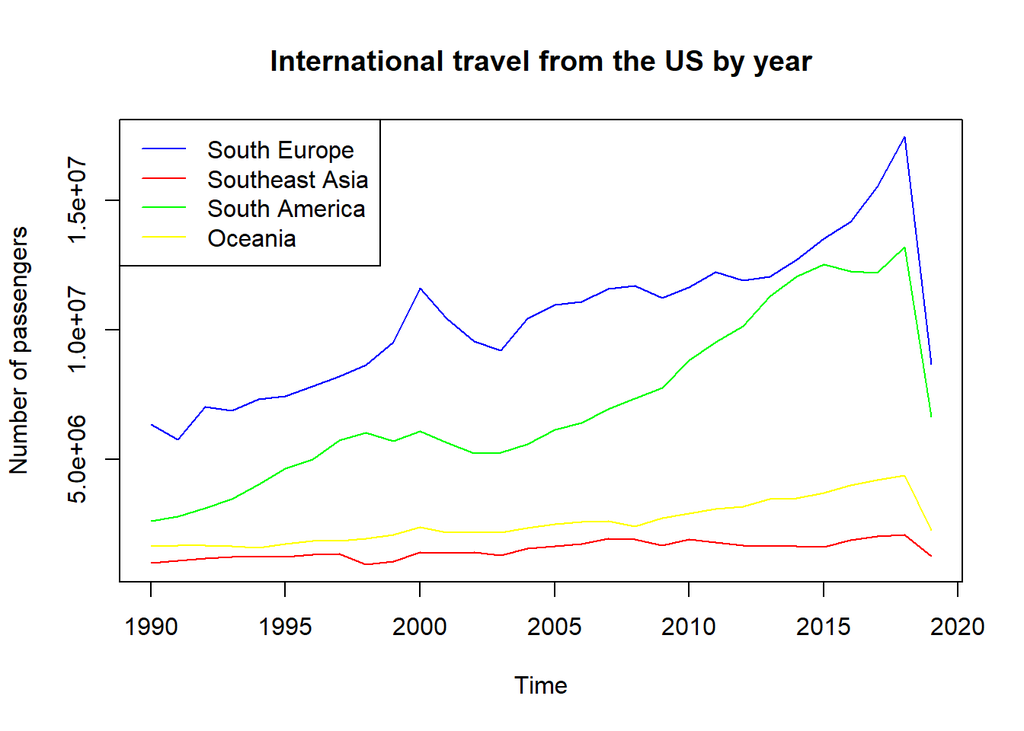

#### By month and year

- Below, we aggregate the data to the monthly level and plot.

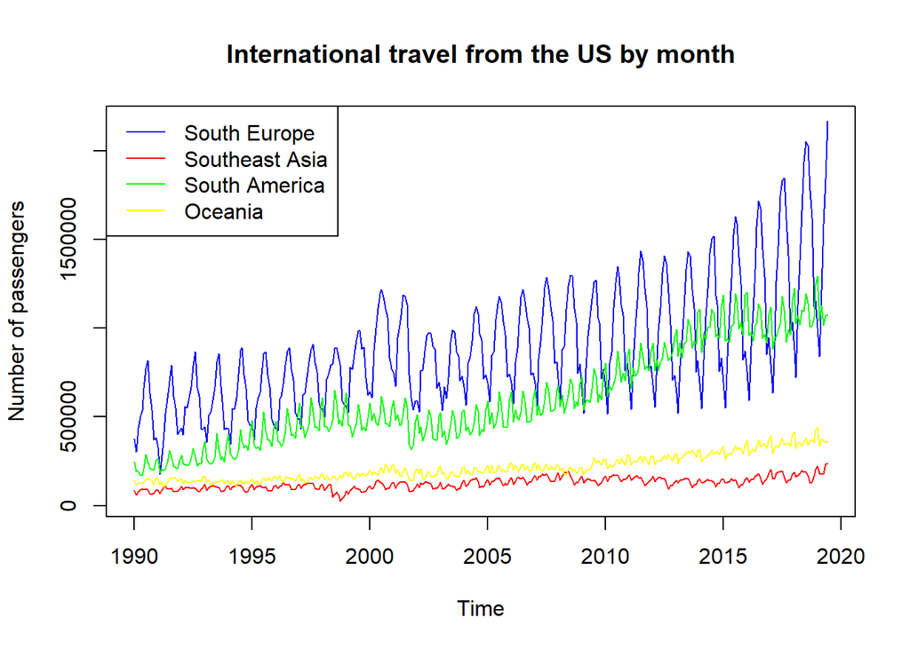

### Step 5. Pre-processing and insights

#### ACF/PACF

- The data is non-stationary having a positive trend.
- Further, it follows a seasonal pattern with a non-constant variance over time.

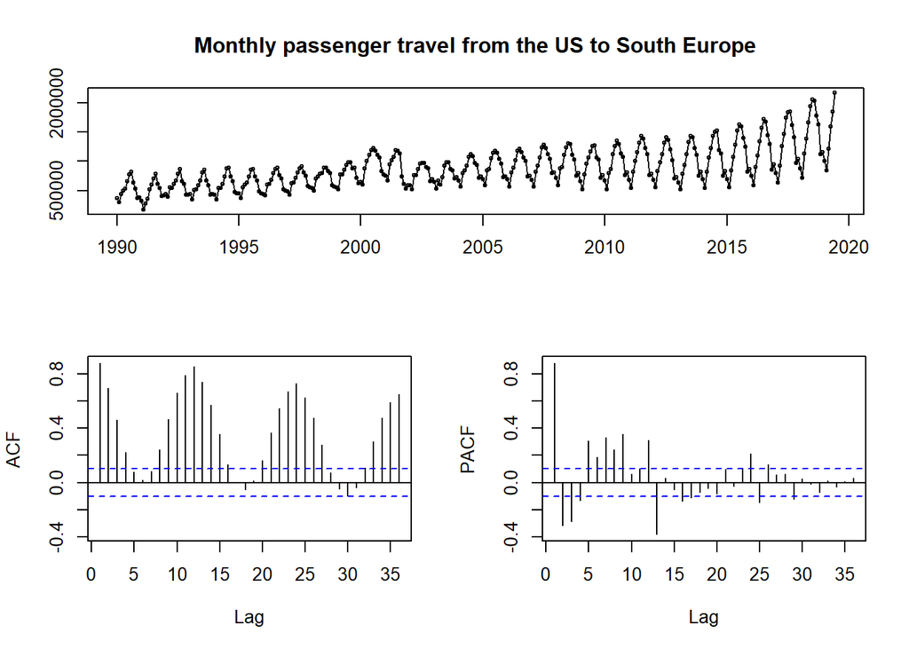

#### Box Cox

- The Box-Cox transformation leads to a more constant variance over time.

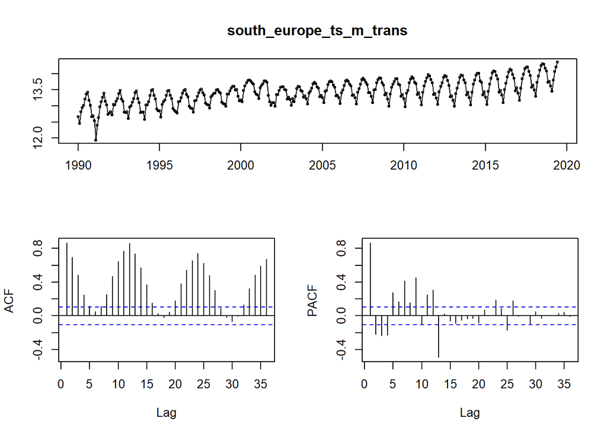

#### Stationarity

- The null hypothesis for the KPSS test is that the data is stationary.
- Large p-values are indicative of stationarity and small p-values suggest non-stationarity.
- For this data, the p-value is 0.01 and hence the data is non-stationary at a 5% significance level.

```
##
##  KPSS Test for Level Stationarity
##
## data:  south_europe_ts_m
## KPSS Level = 4.1392, Truncation lag parameter = 4, p-value = 0.01
```

#### Seasonal decomposition

- The appropriate Holt-Winters method for this data set is multiplicative, because the magnitude of the seasonal pattern increases over time.
- The additive Holt-Winters method would be used if the seasonal fluctuation does not change in magnitude over time.

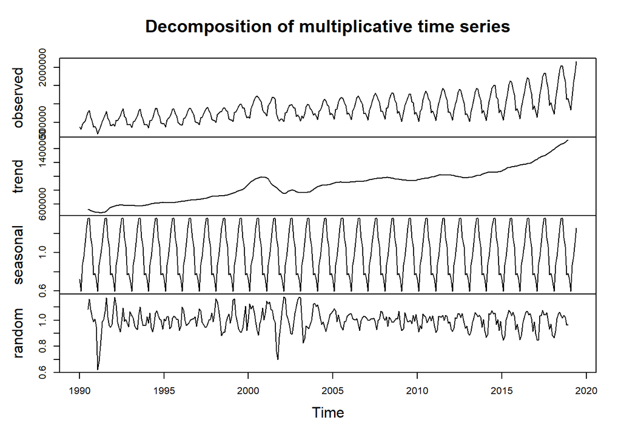

#### Deseasonalizing

- After deseasonalizing and detrending the data, we can observe no seasonality in the data anymore.
- In the PACF, there is a cutoff at lag 12 and 24 (P could be 1 or 2).
- The ACF cutoff at lag 12 (Q could be 1).

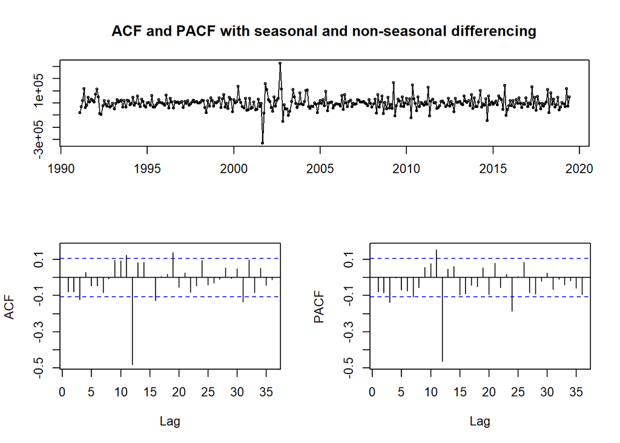

### Step 6. Modeling preparation

#### Addressing stationarity for modeling

- From our exploration, we found that the data were not stationary. Therefore, we need to correct for stationarity before modeling models that do not automatically difference the data or account for stationarity.

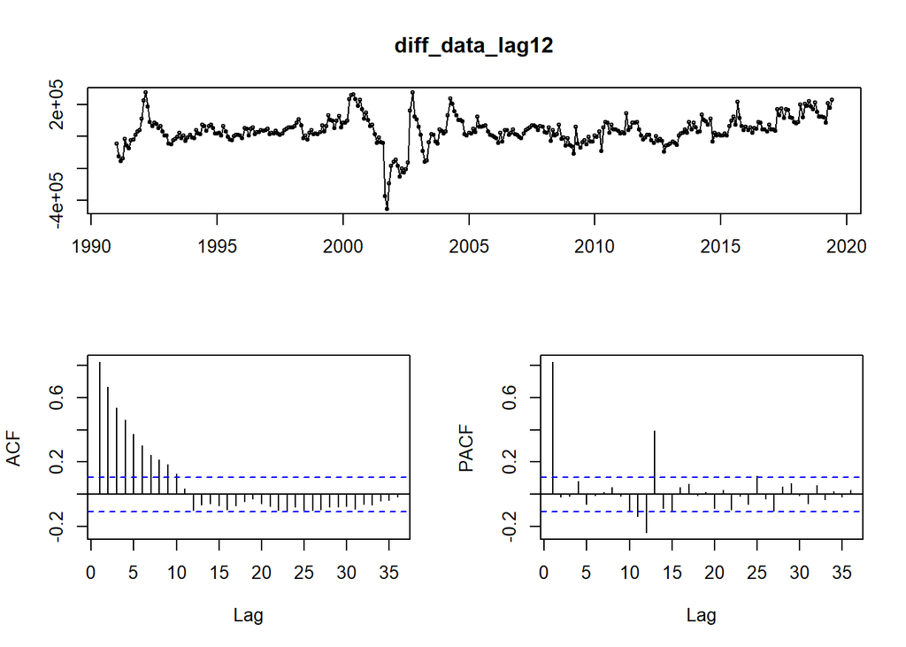

```
##
##  Augmented Dickey-Fuller Test
##
## data:  diff_data_lag12
## Dickey-Fuller = -4.4625, Lag order = 6, p-value = 0.01
## alternative hypothesis: stationary
```

```
##
##  KPSS Test for Level Stationarity
##
## data:  diff_data_lag12
## KPSS Level = 0.47713, Truncation lag parameter = 4, p-value =
## 0.04682
```

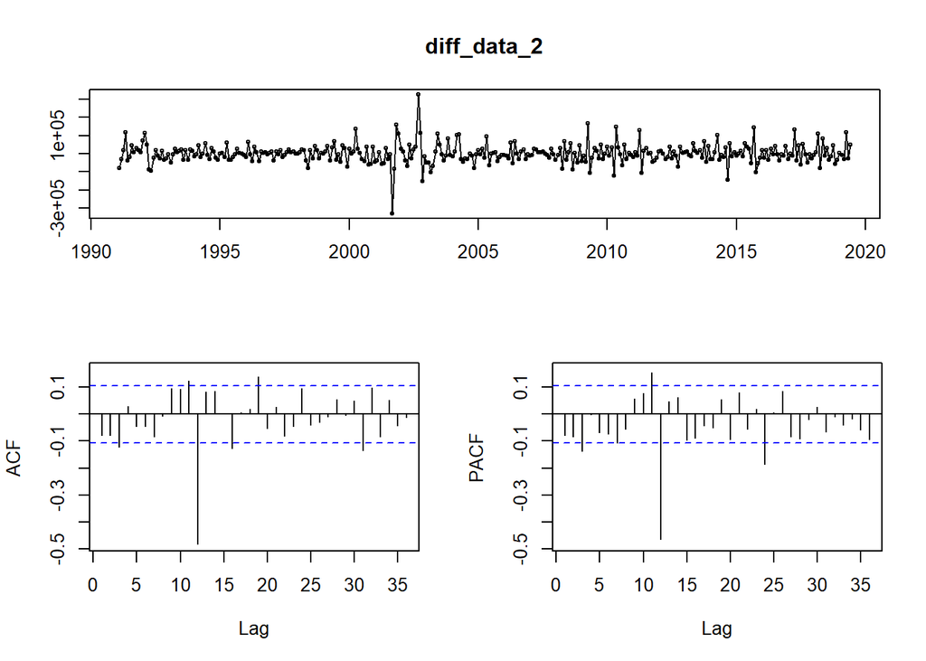

```
##
##  Augmented Dickey-Fuller Test
##
## data:  diff_data_2
## Dickey-Fuller = -9.1006, Lag order = 6, p-value = 0.01
## alternative hypothesis: stationary
```

```
##
##  KPSS Test for Level Stationarity
##
## data:  diff_data_2
## KPSS Level = 0.022029, Truncation lag parameter = 4, p-value = 0.1
```

### Step 7. Modeling

#### Average

- Notes:
  - Average Forecast = Poor performance

```
##
## Forecast method: Mean
##
## Model Information:
## $mu
## [1] 1067389
##
## $mu.se
## [1] 29768.8
##
## $sd
## [1] 334154
##
## $bootstrap
## [1] FALSE
##
## $call
## meanf(y = train, h = length(test))
##
##
## Error measures:
##                         ME     RMSE      MAE       MPE     MAPE     MASE
## Training set -8.123646e-11 332825.3 279369.3 -10.77332 29.71691 4.497258
##                   ACF1
## Training set 0.7969555
##
## Forecasts:
##          Point Forecast    Lo 80   Hi 80  Lo 95   Hi 95
## Jul 2018        1067389 635173.5 1499605 403438 1731341
## Aug 2018        1067389 635173.5 1499605 403438 1731341
## Sep 2018        1067389 635173.5 1499605 403438 1731341
## Oct 2018        1067389 635173.5 1499605 403438 1731341
## Nov 2018        1067389 635173.5 1499605 403438 1731341
## Dec 2018        1067389 635173.5 1499605 403438 1731341
## Jan 2019        1067389 635173.5 1499605 403438 1731341
## Feb 2019        1067389 635173.5 1499605 403438 1731341
## Mar 2019        1067389 635173.5 1499605 403438 1731341
## Apr 2019        1067389 635173.5 1499605 403438 1731341
## May 2019        1067389 635173.5 1499605 403438 1731341
## Jun 2019        1067389 635173.5 1499605 403438 1731341
```

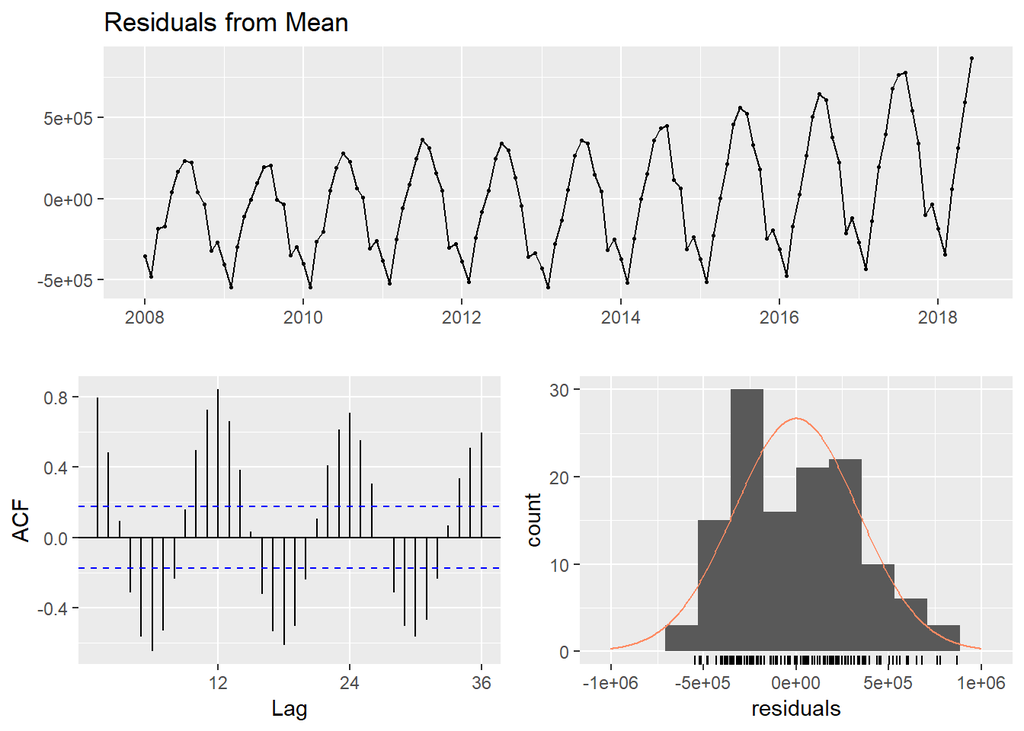

```
##
##  Ljung-Box test
##
## data:  Residuals from Mean
## Q* = 894.98, df = 23, p-value < 2.2e-16
##
## Model df: 1.   Total lags used: 24
```

```
##
## Forecast method: Mean
##
## Model Information:
## $mu
## [1] 1017.302
##
## $mu.se
## [1] 4606.649
##
## $sd
## [1] 51709.5
##
## $bootstrap
## [1] FALSE
##
## $call
## meanf(y = train_diff, h = length(test_diff))
##
##
## Error measures:
##                         ME    RMSE      MAE      MPE     MAPE      MASE
## Training set -5.313422e-13 51503.9 37183.04 99.66051 105.1791 0.6029007
##                    ACF1
## Training set -0.4786215
##
## Forecasts:
##          Point Forecast     Lo 80    Hi 80     Lo 95    Hi 95
## Jul 2018       1017.302 -65867.05 67901.65 -101727.5 103762.1
## Aug 2018       1017.302 -65867.05 67901.65 -101727.5 103762.1
## Sep 2018       1017.302 -65867.05 67901.65 -101727.5 103762.1
## Oct 2018       1017.302 -65867.05 67901.65 -101727.5 103762.1
## Nov 2018       1017.302 -65867.05 67901.65 -101727.5 103762.1
## Dec 2018       1017.302 -65867.05 67901.65 -101727.5 103762.1
## Jan 2019       1017.302 -65867.05 67901.65 -101727.5 103762.1
## Feb 2019       1017.302 -65867.05 67901.65 -101727.5 103762.1
## Mar 2019       1017.302 -65867.05 67901.65 -101727.5 103762.1
## Apr 2019       1017.302 -65867.05 67901.65 -101727.5 103762.1
## May 2019       1017.302 -65867.05 67901.65 -101727.5 103762.1
## Jun 2019       1017.302 -65867.05 67901.65 -101727.5 103762.1
```

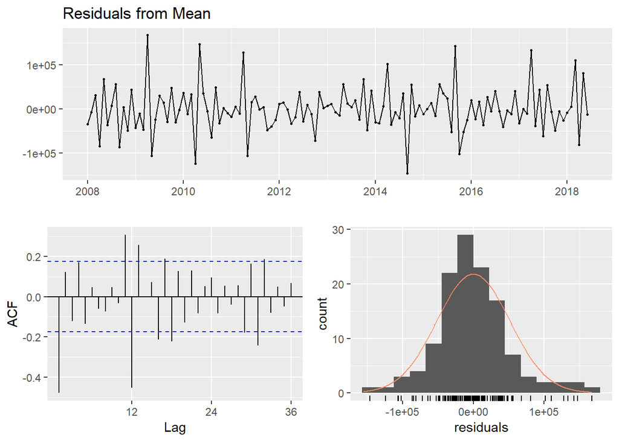

```
##
##  Ljung-Box test
##
## data:  Residuals from Mean
## Q* = 124.05, df = 23, p-value = 7.772e-16
##
## Model df: 1.   Total lags used: 24
```

#### Naive

- Notes:
  - Naive forecast uses the last point recorded.
  - ACF shows that there is seasonality and the residuals are far from white noise.
  - Terrible performance.

```
##
## Forecast method: Naive method
##
## Model Information:
## Call: naive(y = train, h = length(test))
##
## Residual sd: 195699.5334
##
## Error measures:
##                    ME     RMSE      MAE       MPE     MAPE     MASE
## Training set 9774.624 195699.5 167716.8 -1.433922 17.58006 2.699888
##                   ACF1
## Training set 0.3558061
##
## Forecasts:
##          Point Forecast   Lo 80   Hi 80     Lo 95   Hi 95
## Jul 2018        1937351 1686552 2188150 1553787.0 2320915
## Aug 2018        1937351 1582668 2292034 1394909.5 2479792
## Sep 2018        1937351 1502954 2371748 1272998.6 2601703
## Oct 2018        1937351 1435753 2438949 1170222.9 2704479
## Nov 2018        1937351 1376547 2498155 1079675.7 2795026
## Dec 2018        1937351 1323021 2551681  997814.8 2876887
## Jan 2019        1937351 1273799 2600903  922535.9 2952166
## Feb 2019        1937351 1227984 2646718  852468.1 3022234
## Mar 2019        1937351 1184954 2689748  786658.9 3088043
## Apr 2019        1937351 1144255 2730447  724415.0 3150287
## May 2019        1937351 1105545 2769157  665213.0 3209489
## Jun 2019        1937351 1068558 2806144  608646.2 3266056
```

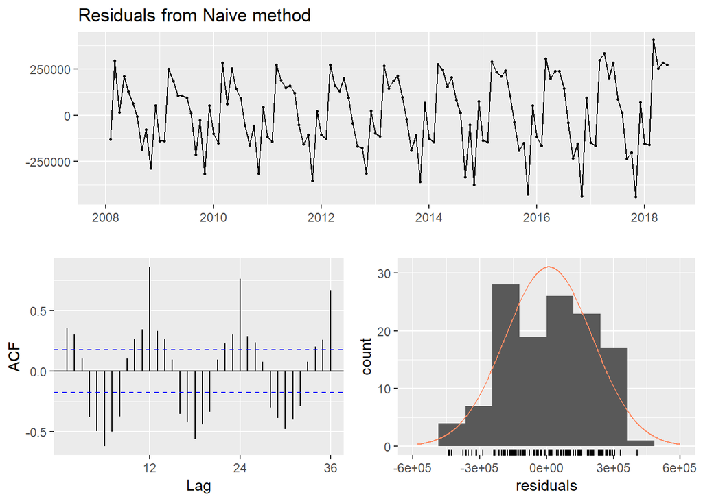

```
##
##  Ljung-Box test
##
## data:  Residuals from Naive method
## Q* = 594.29, df = 24, p-value < 2.2e-16
##
## Model df: 0.   Total lags used: 24
```

```
##
## Forecast method: Naive method
##
## Model Information:
## Call: naive(y = train_diff, h = length(test_diff))
##
## Residual sd: 88862.2045
##
## Error measures:
##                  ME    RMSE      MAE      MPE     MAPE     MASE       ACF1
## Training set 177.72 88862.2 66277.64 85.99554 473.9822 1.074652 -0.7023049
##
## Forecasts:
##          Point Forecast     Lo 80    Hi 80     Lo 95    Hi 95
## Jul 2018         -11362 -125243.5 102519.5 -185528.7 162804.7
## Aug 2018         -11362 -172414.8 149690.8 -257670.9 234946.9
## Sep 2018         -11362 -208610.5 185886.5 -313027.6 290303.6
## Oct 2018         -11362 -239125.0 216401.0 -359695.4 336971.4
## Nov 2018         -11362 -266008.8 243284.8 -400810.6 378086.6
## Dec 2018         -11362 -290313.6 267589.6 -437981.6 415257.6
## Jan 2019         -11362 -312664.1 289940.1 -472163.8 449439.8
## Feb 2019         -11362 -333467.5 310743.5 -503979.9 481255.9
## Mar 2019         -11362 -353006.5 330282.5 -533862.2 511138.2
## Apr 2019         -11362 -371486.9 348762.9 -562125.5 539401.5
## May 2019         -11362 -389064.2 366340.2 -589007.7 566283.7
## Jun 2019         -11362 -405859.1 383135.1 -614693.2 591969.2
```

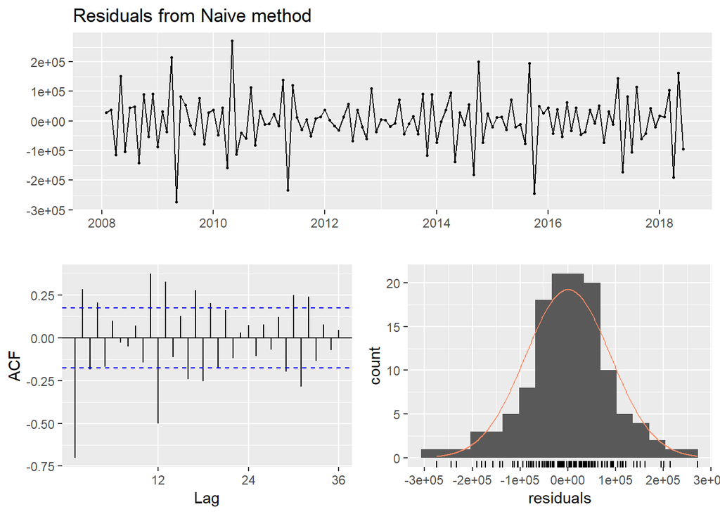

```
##
##  Ljung-Box test
##
## data:  Residuals from Naive method
## Q* = 214.59, df = 24, p-value < 2.2e-16
##
## Model df: 0.   Total lags used: 24
```

#### Seasonal Naive Forecast

- Notes:
  - Seasonal Naive forecast uses previous cycle (last year by month) for predicted values.
  - ACF shows exponential decay, slightly better than plain naive forecast however the residuals are still far from white noise.
  - Seasonal Naive Forecast = Poor performance.

```
##
## Forecast method: Seasonal naive method
##
## Model Information:
## Call: snaive(y = train, h = length(test))
##
## Residual sd: 78756.8465
##
## Error measures:
##                    ME     RMSE     MAE      MPE     MAPE MASE      ACF1
## Training set 41326.71 78756.18 62119.9 3.143089 5.616763    1 0.6741741
##
## Forecasts:
##          Point Forecast   Lo 80   Hi 80     Lo 95     Hi 95
## Jul 2018        1832476 1731545 1933407 1678115.4 1986836.6
## Aug 2018        1845908 1744977 1946839 1691547.4 2000268.6
## Sep 2018        1610247 1509316 1711178 1455886.4 1764607.6
## Oct 2018        1408399 1307468 1509330 1254038.4 1562759.6
## Nov 2018         966982  866051 1067913  812621.4 1121342.6
## Dec 2018        1034770  933839 1135701  880409.4 1189130.6
## Jan 2019         880756  779825  981687  726395.4 1035116.6
## Feb 2019         722212  621281  823143  567851.4  876572.6
## Mar 2019        1129539 1028608 1230470  975178.4 1283899.6
## Apr 2019        1382309 1281378 1483240 1227948.4 1536669.6
## May 2019        1665743 1564812 1766674 1511382.4 1820103.6
## Jun 2019        1937351 1836420 2038282 1782990.4 2091711.6
```

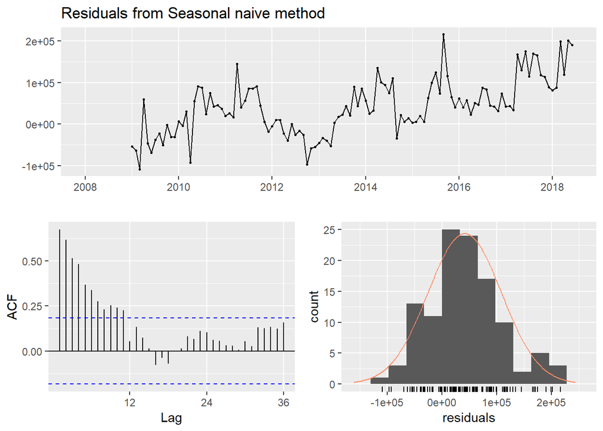

```
##
##  Ljung-Box test
##
## data:  Residuals from Seasonal naive method
## Q* = 236.4, df = 24, p-value < 2.2e-16
##
## Model df: 0.   Total lags used: 24
```

```
##
## Forecast method: Seasonal naive method
##
## Model Information:
## Call: snaive(y = train_diff, h = length(test_diff))
##
## Residual sd: 89169.9542
##
## Error measures:
##                    ME     RMSE      MAE     MPE    MAPE MASE       ACF1
## Training set 785.1228 89169.95 61673.58 393.486 624.467    1 -0.5162777
##
## Forecasts:
##          Point Forecast       Lo 80     Hi 80     Lo 95    Hi 95
## Jul 2018         -59894 -174169.894  54381.89 -234663.9 114875.9
## Aug 2018          55142  -59133.894 169417.89 -119627.9 229911.9
## Sep 2018          -4836 -119111.894 109439.89 -179605.9 169933.9
## Oct 2018         -47554 -161829.894  66721.89 -222323.9 127215.9
## Nov 2018          -4421 -118696.894 109854.89 -179190.9 170348.9
## Dec 2018         -25191 -139466.894  89084.89 -199960.9 149578.9
## Jan 2019          -6834 -121109.894 107441.89 -181603.9 167935.9
## Feb 2019           6355 -107920.894 120630.89 -168414.9 181124.9
## Mar 2019         111275   -3000.894 225550.89  -63494.9 286044.9
## Apr 2019         -79679 -193954.894  34596.89 -254448.9  95090.9
## May 2019          82230  -32045.894 196505.89  -92539.9 256999.9
## Jun 2019         -11362 -125637.894 102913.89 -186131.9 163407.9
```

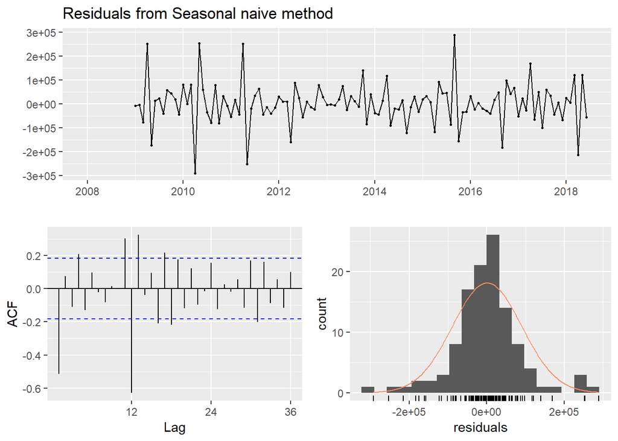

```
##
##  Ljung-Box test
##
## data:  Residuals from Seasonal naive method
## Q* = 153.27, df = 24, p-value < 2.2e-16
##
## Model df: 0.   Total lags used: 24
```

#### Random Walk w/ Drift

- Notes:
  - Random Walk w/ Drift = Poor Performance
  - rwf() understands the trend but not the seasonality.

```
##
## Forecast method: Random walk with drift
##
## Model Information:
## Call: rwf(y = train, h = length(test), drift = T)
##
## Drift: 9774.624  (se 17482.0319)
## Residual sd: 196241.8171
##
## Error measures:
##                         ME     RMSE      MAE       MPE     MAPE    MASE
## Training set -4.779546e-09 195455.3 167016.8 -2.445516 17.63444 2.68862
##                   ACF1
## Training set 0.3558061
##
## Forecasts:
##          Point Forecast   Lo 80   Hi 80     Lo 95   Hi 95
## Jul 2018        1947126 1694636 2199616 1560975.6 2333276
## Aug 2018        1956900 1598423 2315378 1408655.9 2505145
## Sep 2018        1966675 1525920 2407430 1292597.8 2640752
## Oct 2018        1976449 1465540 2487359 1195081.5 2757817
## Nov 2018        1986224 1412818 2559630 1109274.8 2863173
## Dec 2018        1995999 1365471 2626527 1031689.5 2960308
## Jan 2019        2005773 1322151 2689396  960262.7 3051284
## Feb 2019        2015548 1281982 2749114  893656.4 3137440
## Mar 2019        2025323 1244361 2806284  830945.3 3219700
## Apr 2019        2035097 1208849 2861346  771459.0 3298736
## May 2019        2044872 1175115 2914629  714693.6 3375050
## Jun 2019        2054646 1142906 2966387  660259.6 3449033
```

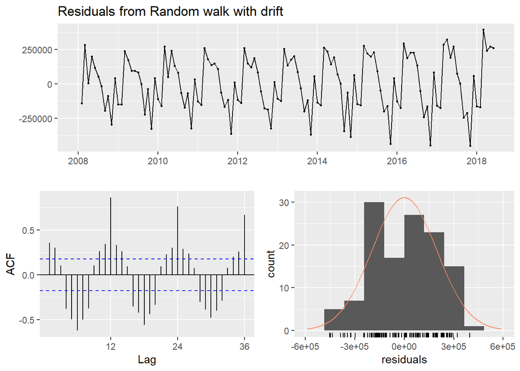

```
##
##  Ljung-Box test
##
## data:  Residuals from Random walk with drift
## Q* = 594.29, df = 23, p-value < 2.2e-16
##
## Model df: 1.   Total lags used: 24
```

```
##
## Forecast method: Random walk with drift
##
## Model Information:
## Call: rwf(y = train_diff, h = length(test_diff), drift = T)
##
## Drift: 177.72  (se 7948.1235)
## Residual sd: 89219.6219
##
## Error measures:
##                        ME     RMSE      MAE      MPE     MAPE     MASE
## Training set 9.494682e-10 88862.03 66273.37 85.93153 474.4479 1.074583
##                    ACF1
## Training set -0.7023049
##
## Forecasts:
##          Point Forecast     Lo 80    Hi 80     Lo 95    Hi 95
## Jul 2018      -11184.28 -125976.6 103608.1 -186744.0 164375.5
## Aug 2018      -11006.56 -173985.3 151972.2 -260261.1 238247.9
## Sep 2018      -10828.84 -211214.4 189556.7 -317292.1 295634.4
## Oct 2018      -10651.12 -242931.5 221629.3 -365893.3 344591.1
## Nov 2018      -10473.40 -271167.6 250220.8 -409170.8 388224.0
## Dec 2018      -10295.68 -296959.8 276368.4 -448710.6 428119.2
## Jan 2019      -10117.96 -320921.2 300685.2 -485450.4 465214.5
## Feb 2019       -9940.24 -343449.5 323569.1 -519998.7 500118.2
## Mar 2019       -9762.52 -364820.0 345294.9 -552776.0 533251.0
## Apr 2019       -9584.80 -385231.8 366062.2 -584087.2 564917.6
## May 2019       -9407.08 -404834.7 386020.5 -614161.4 595347.2
## Jun 2019       -9229.36 -423744.5 405285.8 -643175.6 624716.9
```

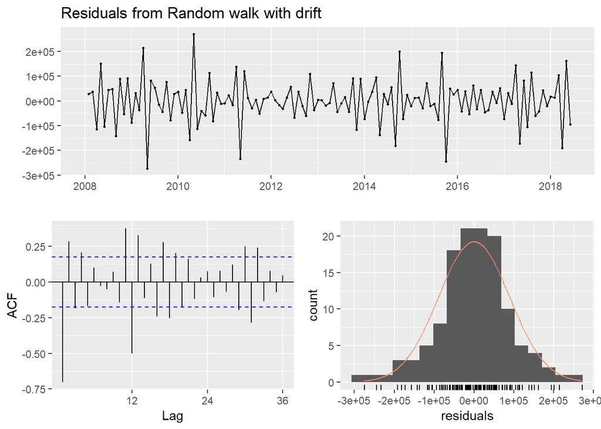

```
##
##  Ljung-Box test
##
## data:  Residuals from Random walk with drift
## Q* = 214.59, df = 23, p-value < 2.2e-16
##
## Model df: 1.   Total lags used: 24
```

#### Holt Winters Forecast

- Notes:
  - Holt Winters - Performance = Not bad
  - HoltWinters() uses heuristic values for the initial states and then estimates the smoothing parameters by optimizing the MSE.

```
##
## Forecast method: HoltWinters
##
## Model Information:
## Holt-Winters exponential smoothing with trend and additive seasonal component.
##
## Call:
## HoltWinters(x = train)
##
## Smoothing parameters:
##  alpha: 0.2725983
##  beta : 0.05765174
##  gamma: 1
##
## Coefficients:
##            [,1]
## a   1392827.670
## b      9690.672
## s1   579622.120
## s2   566911.731
## s3   308317.467
## s4    98653.698
## s5  -348166.271
## s6  -279957.188
## s7  -430593.223
## s8  -586413.675
## s9  -204722.203
## s10   43101.436
## s11  297751.370
## s12  544523.330
##
## Error measures:
##                    ME     RMSE      MAE         MPE     MAPE      MASE
## Training set 7103.252 44813.54 34964.08 -0.05465902 3.354402 0.5628483
##                   ACF1
## Training set 0.3044779
##
## Forecasts:
##          Point Forecast     Lo 80     Hi 80     Lo 95   Hi 95
## Jul 2018      1982140.5 1925185.3 2039095.6 1895035.1 2069246
## Aug 2018      1979120.7 1919845.6 2038395.9 1888467.3 2069774
## Sep 2018      1730217.2 1668464.5 1791969.8 1635774.7 1824660
## Oct 2018      1530244.1 1465862.1 1594626.0 1431780.4 1628708
## Nov 2018      1093114.8 1025957.6 1160271.9  990406.8 1195823
## Dec 2018      1171014.5 1100942.2 1241086.9 1063848.1 1278181
## Jan 2019      1030069.2  956947.4 1103190.9  918239.0 1141899
## Feb 2019       883939.4  807639.5  960239.2  767248.8 1000630
## Mar 2019      1275321.5 1195720.3 1354922.7 1153582.0 1397061
## Apr 2019      1532835.8 1449815.1 1615856.6 1405866.5 1659805
## May 2019      1797176.4 1710622.6 1883730.3 1664803.8 1929549
## Jun 2019      2053639.1 1963443.2 2143835.0 1915696.4 2191582
```

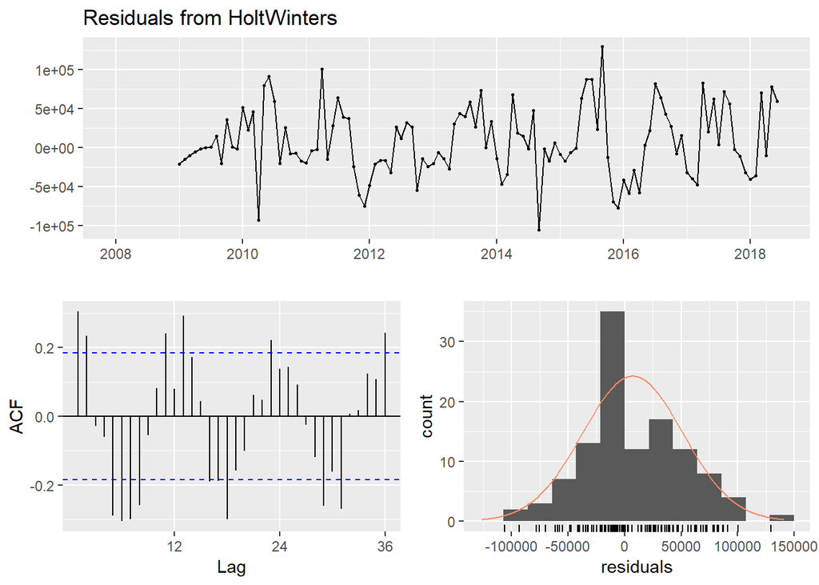

```
##
## Forecast method: HoltWinters
##
## Model Information:
## Holt-Winters exponential smoothing with trend and additive seasonal component.
##
## Call:
## HoltWinters(x = train_diff)
##
## Smoothing parameters:
##  alpha: 0.002411281
##  beta : 0.9675861
##  gamma: 0.2815688
##
## Coefficients:
##            [,1]
## a     6111.6610
## b      157.7557
## s1  -13161.6174
## s2    7393.0471
## s3  -16269.2508
## s4  -30075.9596
## s5  -25717.4551
## s6   -3757.4305
## s7  -16525.1010
## s8   -9551.4187
## s9   24678.8030
## s10   6518.3770
## s11  12830.6336
## s12   3697.9897
##
## Error measures:
##                     ME    RMSE     MAE     MPE     MAPE      MASE
## Training set -1871.851 64488.9 42908.9 61.3341 383.2692 0.6957421
##                    ACF1
## Training set -0.4952463
##
## Forecasts:
##          Point Forecast      Lo 80     Hi 80      Lo 95    Hi 95
## Jul 2018      -6892.201  -89867.96  76083.56 -133792.67 120008.3
## Aug 2018      13820.219  -69156.47  96796.91 -113081.68 140722.1
## Sep 2018      -9684.323  -92663.09  73294.45 -136589.40 117220.8
## Oct 2018     -23333.276 -106315.72  59649.17 -150243.97 103577.4
## Nov 2018     -18817.016 -101805.18  64171.15 -145736.46 108102.4
## Dec 2018       3300.764  -79695.62  86297.15 -123631.25 130232.8
## Jan 2019      -9309.150  -92316.70  73698.40 -136258.25 117639.9
## Feb 2019      -2177.713  -85199.83  80844.41 -129149.09 124793.7
## Mar 2019      32210.265  -50830.27 115250.80  -94789.28 159209.8
## Apr 2019      14207.594  -68855.66  97270.85 -112826.69 141241.9
## May 2019      20677.607  -62413.11 103768.32 -106398.67 147753.9
## Jun 2019      11702.718  -71420.64  94826.08 -115423.49 138828.9
```

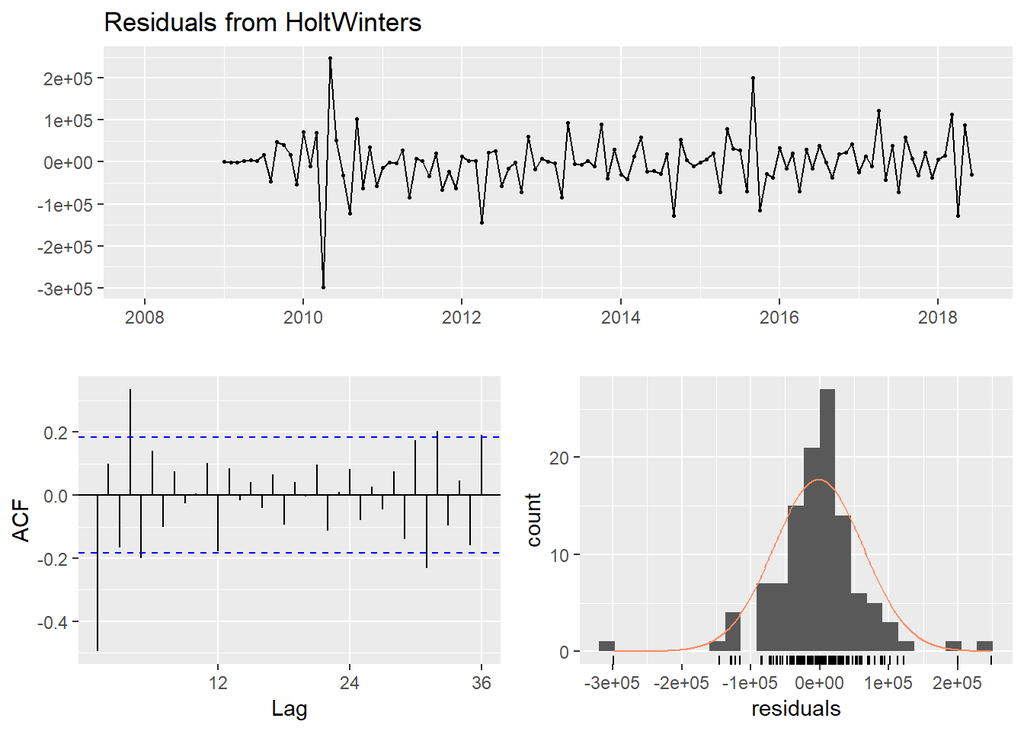

#### SES

- Notes:
  - We fit two SES models below. First, we fit a regular simple exponential smoothing model. However, SES is suitable for data with no trend or seasonal pattern. Therefore, we see poor performance. Then, we try SES on our differenced data with trend and seasonality removed.

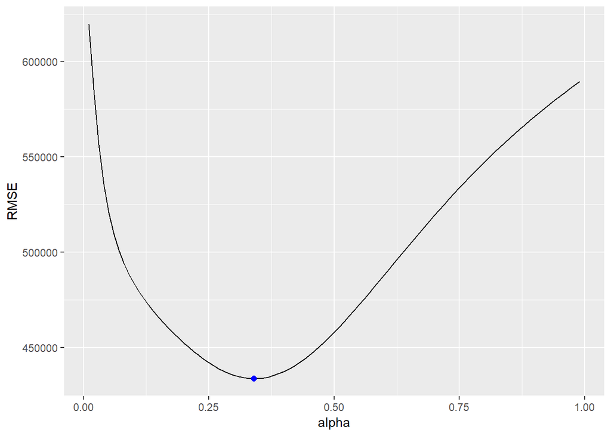

```
## # A tibble: 1 x 2
##   alpha    RMSE
##   <dbl>   <dbl>
## 1  0.34 433717.
```

```
##
## Forecast method: Simple exponential smoothing
##
## Model Information:
## Simple exponential smoothing
##
## Call:
##  ses(y = train, h = length(test), alpha = 0.34)
##
##   Smoothing parameters:
##     alpha = 0.34
##
##   Initial states:
##     l = 811492.826
##
##   sigma:  302786.2
##
##      AIC     AICc      BIC
## 3791.793 3791.890 3797.465
##
## Error measures:
##                    ME     RMSE      MAE       MPE     MAPE     MASE
## Training set 16880.01 300373.5 267144.7 -5.845617 27.52779 4.300469
##                   ACF1
## Training set 0.7571027
##
## Forecasts:
##          Point Forecast     Lo 80   Hi 80    Lo 95   Hi 95
## Jul 2018        1534632 1146596.2 1922668 941182.3 2128082
## Aug 2018        1534632 1124781.0 1944484 907818.8 2161446
## Sep 2018        1534632 1104069.6 1965195 876143.5 2193121
## Oct 2018        1534632 1084309.8 1984955 845923.4 2223341
## Nov 2018        1534632 1065381.3 2003883 816974.8 2252290
## Dec 2018        1534632 1047187.3 2022077 789149.5 2280115
## Jan 2019        1534632 1029648.4 2039616 762326.1 2306939
## Feb 2019        1534632 1012698.5 2056566 736403.5 2332861
## Mar 2019        1534632  996282.1 2072983 711296.7 2357968
## Apr 2019        1534632  980351.6 2088913 686933.1 2382332
## May 2019        1534632  964866.4 2104398 663250.5 2406014
## Jun 2019        1534632  949791.0 2119474 640194.7 2429070
```

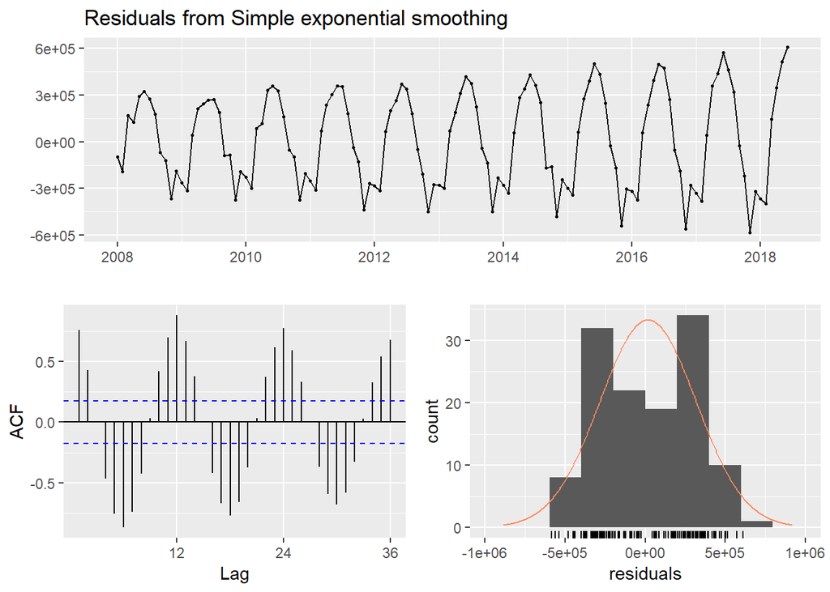

```
##
##  Ljung-Box test
##
## data:  Residuals from Simple exponential smoothing
## Q* = 1136.3, df = 22, p-value < 2.2e-16
##
## Model df: 2.   Total lags used: 24
```

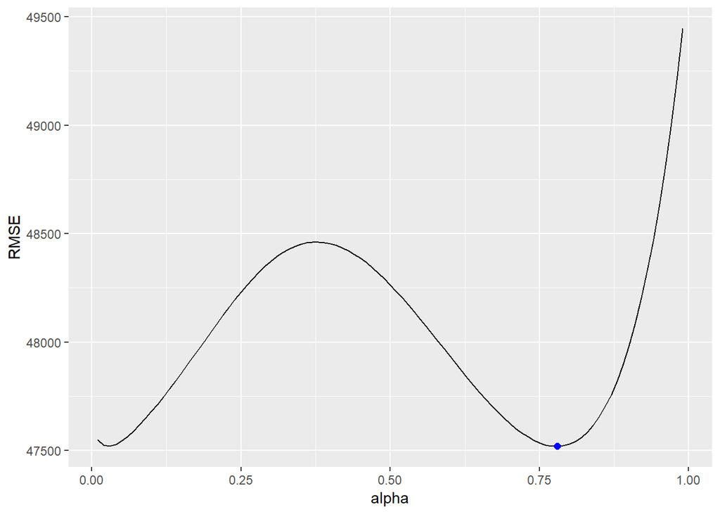

```
## # A tibble: 1 x 2
##   alpha   RMSE
##   <dbl>  <dbl>
## 1  0.78 47519.
```

```
##
## Forecast method: Simple exponential smoothing
##
## Model Information:
## Simple exponential smoothing
##
## Call:
##  ses(y = train_diff, h = length(test_diff), alpha = 0.78)
##
##   Smoothing parameters:
##     alpha = 0.78
##
##   Initial states:
##     l = -26594.9287
##
##   sigma:  77354.39
##
##      AIC     AICc      BIC
## 3447.906 3448.003 3453.578
##
## Error measures:
##                    ME     RMSE      MAE      MPE     MAPE      MASE
## Training set 302.8667 76738.01 56070.32 90.91896 353.2211 0.9091466
##                    ACF1
## Training set -0.6415545
##
## Forecasts:
##          Point Forecast      Lo 80    Hi 80     Lo 95    Hi 95
## Jul 2018       3170.806  -95962.83 102304.4 -148441.0 154782.6
## Aug 2018       3170.806 -122553.16 128894.8 -189107.4 195449.0
## Sep 2018       3170.806 -144428.49 150770.1 -222562.8 228904.5
## Oct 2018       3170.806 -163456.29 169797.9 -251663.4 258005.0
## Nov 2018       3170.806 -180523.58 186865.2 -277765.5 284107.1
## Dec 2018       3170.806 -196134.65 202476.3 -301640.6 307982.2
## Jan 2019       3170.806 -210608.76 216950.4 -323776.8 330118.4
## Feb 2019       3170.806 -224163.18 230504.8 -344506.5 350848.1
## Mar 2019       3170.806 -236953.70 243295.3 -364067.9 370409.5
## Apr 2019       3170.806 -249096.54 255438.2 -382638.8 388980.4
## May 2019       3170.806 -260681.15 267022.8 -400355.9 406697.5
## Jun 2019       3170.806 -271778.08 278119.7 -417327.2 423668.8
```

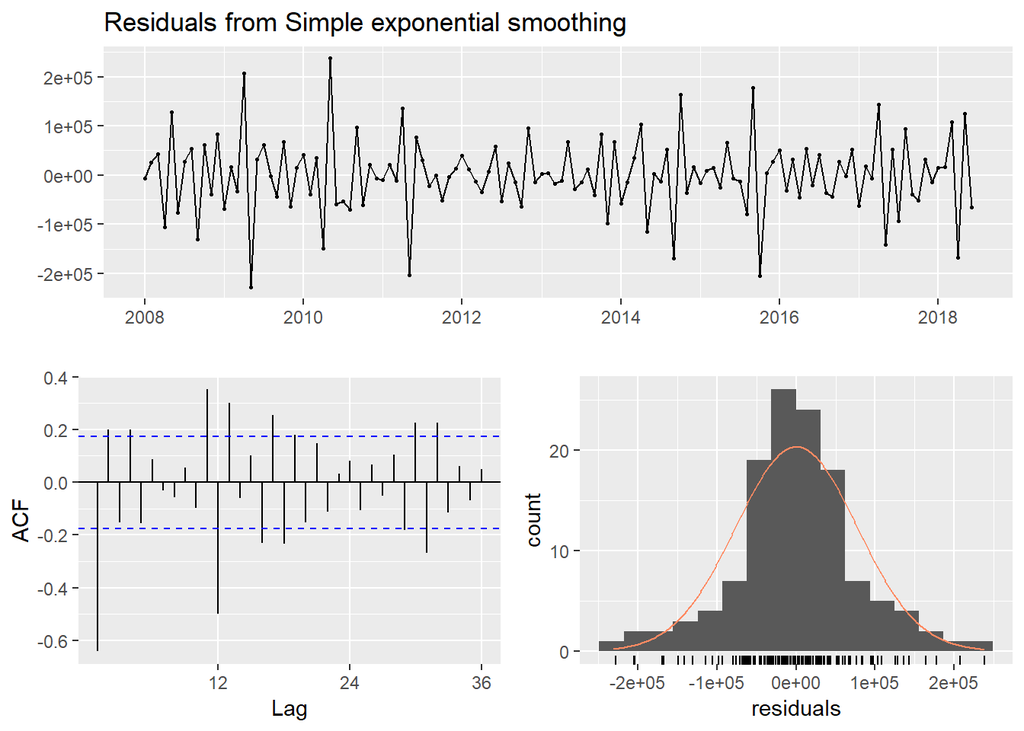

```
##
##  Ljung-Box test
##
## data:  Residuals from Simple exponential smoothing
## Q* = 181.09, df = 22, p-value < 2.2e-16
##
## Model df: 2.   Total lags used: 24
```

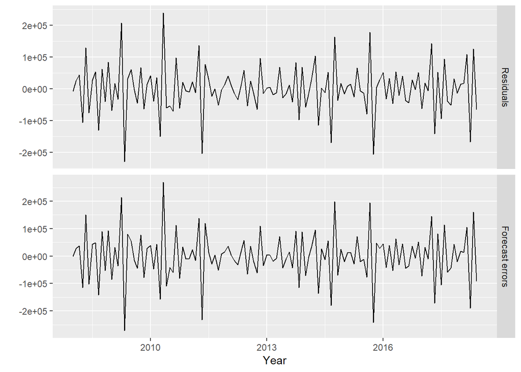

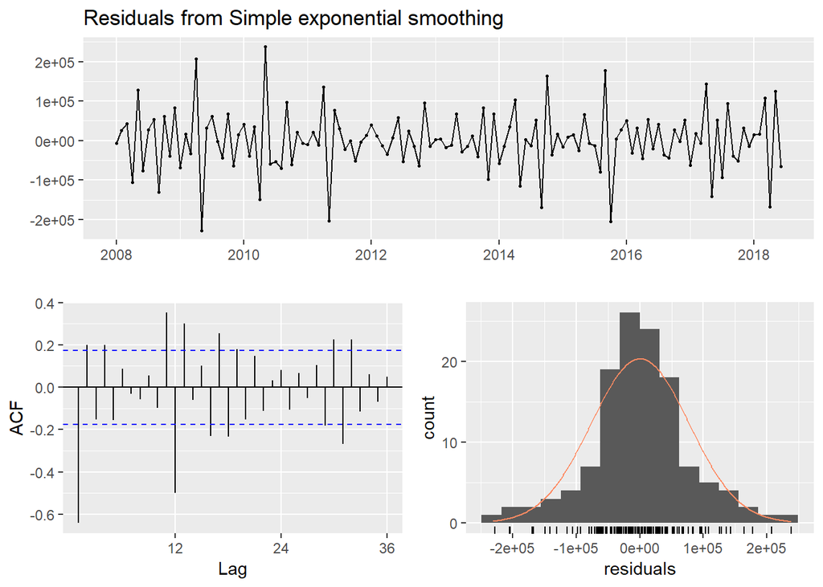

```
##
##  Ljung-Box test
##
## data:  Residuals from Simple exponential smoothing
## Q* = 181.09, df = 22, p-value < 2.2e-16
##
## Model df: 2.   Total lags used: 24
```

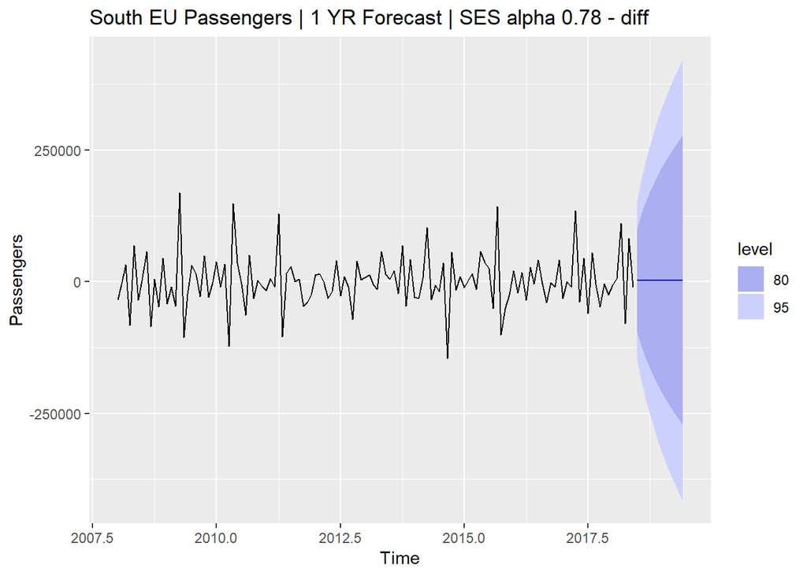

```
##                     ME     RMSE      MAE      MPE      MAPE      MASE
## Training set 302.86666 76738.01 56070.32 90.91896 353.22107 0.9091466
## Test set      52.94388 47519.47 38226.88 99.12958  99.12958 0.6198259
##                    ACF1 Theil's U
## Training set -0.6415545        NA
## Test set     -0.3618665 0.8958322
```

#### ETS

- Notes: Below, we fit multiple ETS models, beginning with a plot of the decomposition of our data.

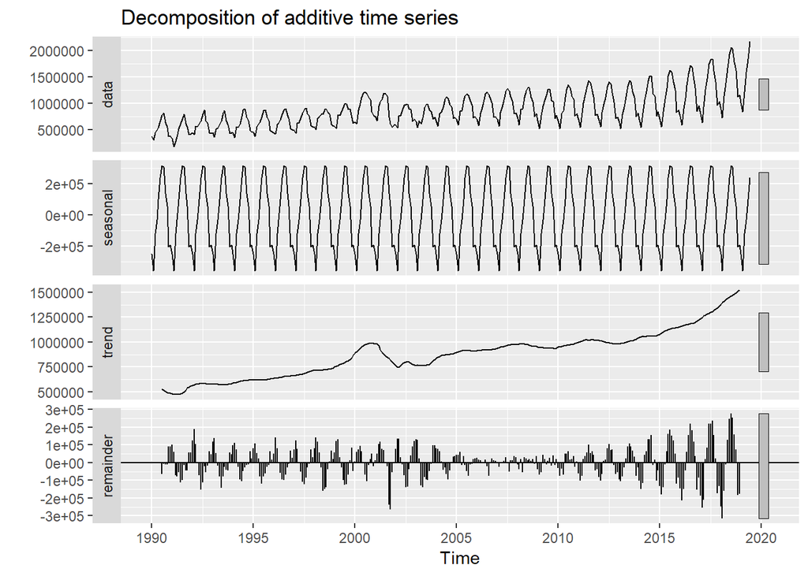

- Decomposition shows us the patterns of our ETS we can then choose:
  - error: additive (“A”), multiplicative (“M”), unknown (“Z”)
  - trend: none (“N”), additive (“A”), multiplicative (“M”), unknown (“Z”)
  - seasonality: none (“N”), additive (“A”), multiplicative (“M”), unknown (“Z”)
- ets() estimates both the initial states and smoothing parameters by optimizing the likelihood function (which is only equivalent to optimizing the MSE for the linear additive models). If you want the model to select the best option, use = “ZZZ” and the “optimal” model will be selected.

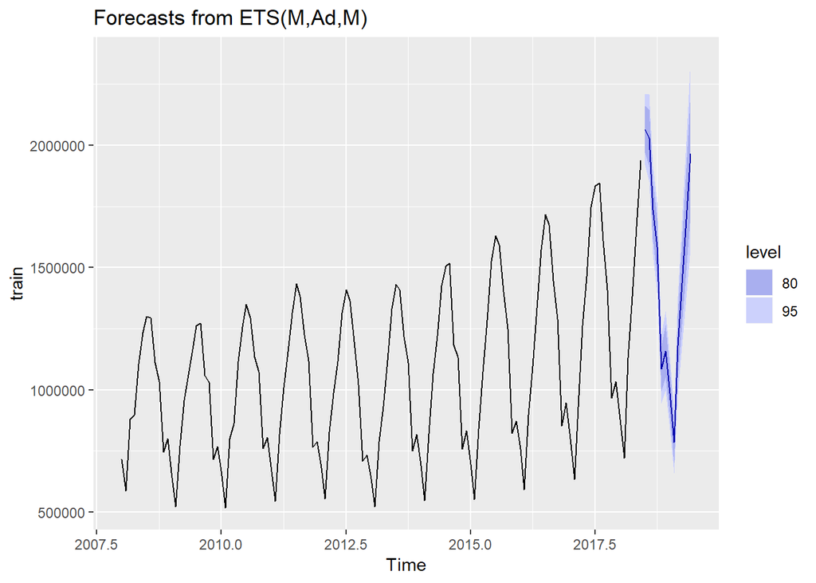

```
## ETS(M,Ad,M)
##
## Call:
##  ets(y = train)
##
##   Smoothing parameters:
##     alpha = 0.7558
##     beta  = 0.0062
##     gamma = 1e-04
##     phi   = 0.9777
##
##   Initial states:
##     l = 1023297.7947
##     b = -2262.537
##     s = 0.785 0.7372 1.0767 1.1813 1.3832 1.4098
##            1.3215 1.1426 0.968 0.7966 0.5307 0.6675
##
##   sigma:  0.0359
##
##      AIC     AICc      BIC
## 3273.247 3279.639 3324.300
##
## Training set error measures:
##                   ME     RMSE      MAE       MPE     MAPE      MASE
## Training set 4714.92 35958.65 25281.32 0.3450024 2.393413 0.4069762
##                    ACF1
## Training set -0.0564455
```

```
##                    ME     RMSE      MAE       MPE     MAPE      MASE
## Training set  4714.92 35958.65 25281.32 0.3450024 2.393413 0.4069762
## Test set     59890.33 89410.83 62377.01 3.8130139 3.946629 1.0041388
##                    ACF1 Theil's U
## Training set -0.0564455        NA
## Test set      0.5515216 0.2900773
```

- ETS() will find parameters for you, but we also tried to optimize the parameters on our own:

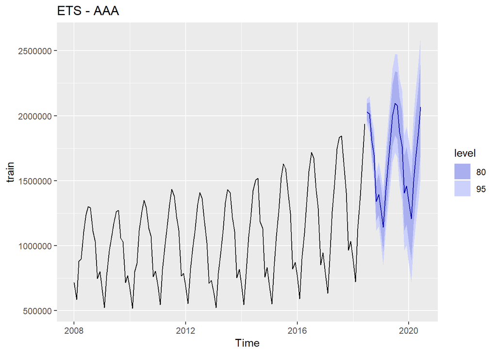

```
## ETS(A,A,A)
##
## Call:
##  ets(y = train, model = "AAA")
##
##   Smoothing parameters:
##     alpha = 0.9999
##     beta  = 0.0113
##     gamma = 1e-04
##
##   Initial states:
##     l = 1005860.9358
##     b = -1314.9562
##     s = -232084.2 -281571.7 84923.29 198953.4 406887.3 430297.8
##            342747.1 150083.5 -31665.52 -215820 -495735.2 -357015.7
##
##   sigma:  50157.63
##
##      AIC     AICc      BIC
## 3353.638 3359.305 3401.855
##
## Training set error measures:
##                    ME     RMSE      MAE       MPE     MAPE      MASE
## Training set 4720.584 46864.94 34369.72 0.3300935 3.302626 0.5532804
##                    ACF1
## Training set 0.04490566
```

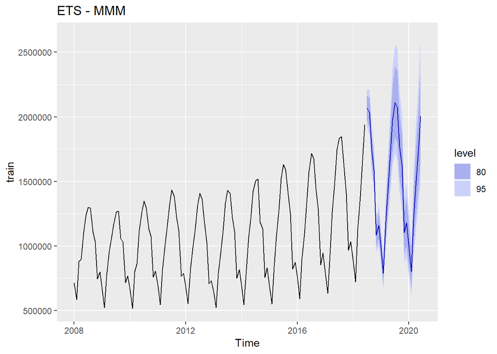

```
## ETS(M,Md,M)
##
## Call:
##  ets(y = train, model = "MMM")
##
##   Smoothing parameters:
##     alpha = 0.7308
##     beta  = 0.0073
##     gamma = 1e-04
##     phi   = 0.9727
##
##   Initial states:
##     l = 1023316.2426
##     b = 0.9976
##     s = 0.7835 0.7352 1.0762 1.1823 1.3835 1.4097
##            1.3202 1.1428 0.9691 0.7982 0.5314 0.668
##
##   sigma:  0.0359
##
##      AIC     AICc      BIC
## 3272.836 3279.228 3323.889
##
## Training set error measures:
##                    ME     RMSE      MAE       MPE     MAPE      MASE
## Training set 4669.134 35897.27 25308.33 0.3287808 2.394707 0.4074109
##                     ACF1
## Training set -0.02861872
```

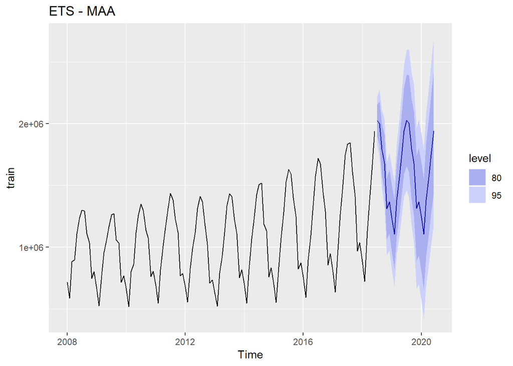

```
## ETS(M,Ad,A)
##
## Call:
##  ets(y = train, model = "MAA")
##
##   Smoothing parameters:
##     alpha = 0.9602
##     beta  = 1e-04
##     gamma = 0.0398
##     phi   = 0.98
##
##   Initial states:
##     l = 1012147.6299
##     b = 1014.8246
##     s = -232084.5 -281571.5 84923.45 198953.5 406887.5 430297.6
##            342645.7 146547.2 -31665.33 -222107 -483162.3 -359664.3
##
##   sigma:  0.0496
##
##      AIC     AICc      BIC
## 3354.773 3361.166 3405.826
##
## Training set error measures:
##                    ME     RMSE      MAE       MPE     MAPE     MASE
## Training set 4410.507 48254.26 35326.47 0.2640174 3.419934 0.568682
##                    ACF1
## Training set 0.06622826
```

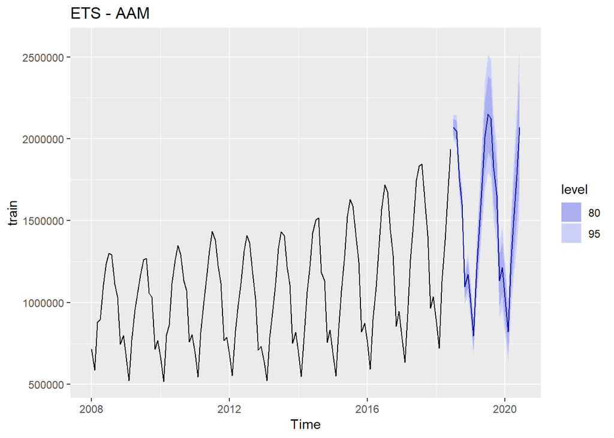

```
## ETS(A,Ad,M)
##
## Call:
##  ets(y = train, model = "AAM", restrict = FALSE)
##
##   Smoothing parameters:
##     alpha = 0.7381
##     beta  = 0.0171
##     gamma = 1e-04
##     phi   = 0.9775
##
##   Initial states:
##     l = 1023297.8203
##     b = -3778.7352
##     s = 0.7849 0.7353 1.0775 1.1885 1.3885 1.4087
##            1.3214 1.1389 0.9635 0.7964 0.5291 0.6673
##
##   sigma:  38306.15
##
##      AIC     AICc      BIC
## 3286.558 3292.950 3337.611
##
## Training set error measures:
##                    ME     RMSE      MAE       MPE     MAPE      MASE
## Training set 3842.729 35628.41 24905.46 0.3159739 2.376534 0.4009256
##                     ACF1
## Training set -0.05422164
```